# Администрирование сетевых подсистем

## Проверка работы Dovecot

С помощью команды retr 1 получим первое письмо из списка. Мы видим, что вывелось содержание письма и информация о первом письме.

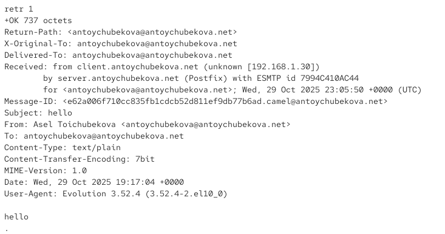

Первое письмо из списка

## Проверка работы Dovecot

С помощью команды dele 2 удалим второе письмо из списка. Мы видим, что 2ое письмо успешно удалено, с помощью команды list удостоверимся, что второго письма нет в списке.

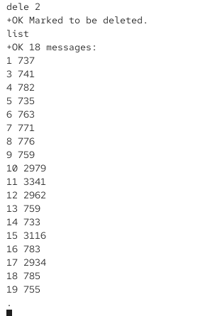

Удаление второго письма

## Проверка работы Dovecot

С помощью команды quit завершим сеанс работы с telnet.

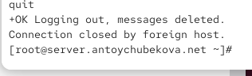

Завершение сеанса работы с telnet

## Внесение изменений в настройки внутреннего окружения виртуальной машины

На виртуальной машине server перейдtv в каталог для внесения изменений в настройки внутреннего окружения /vagrant/provision/server/. В соответствующие подкаталоги поместим конфигурационные файлы Dovecot.

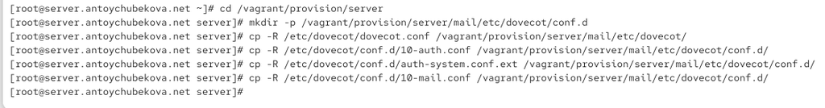

Внесение изменений в настройки внутреннего окружения вм

## Внесение изменений в настройки внутреннего окружения виртуальной машины

Внесем изменения в файл /vagrant/provision/server/mail.sh, добавив в него строки с установкой Dovecot и Telnet, настройкой межсетевого экрана, настройкой Postfix в части задания месторасположения почтового ящика, перезагрузкой Postfix и запуском Dovecot.

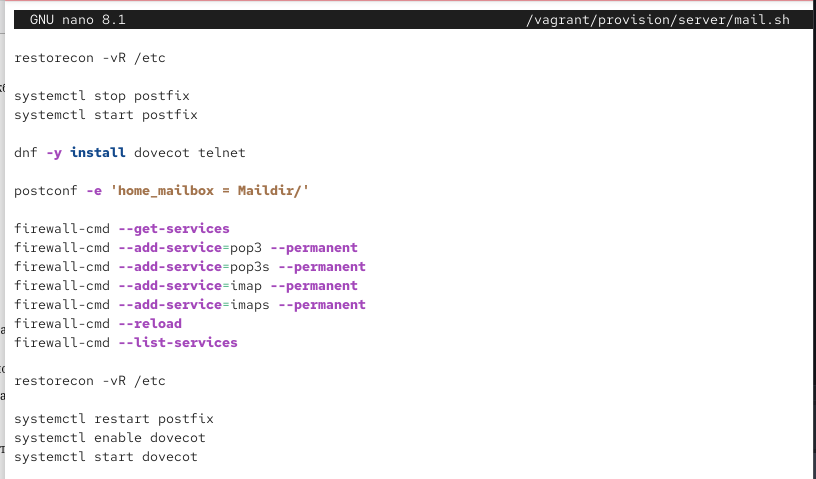

Редактирование исполняемого файла

## Внесение изменений в настройки внутреннего окружения виртуальной машины

На виртуальной машине client в каталоге /vagrant/provision/client скорректируем файл mail.sh, прописав в нём установку evolution.

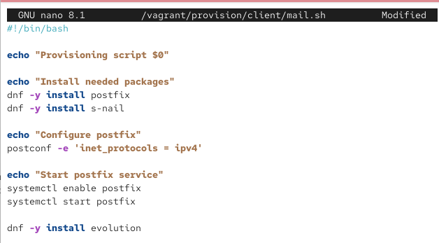

Редактирование исполняемого файла

# Выводы

## Выводы

В ходе выполнения лабораторной работы №9 я приобрела практические навыки по установке и простейшему конфигурированию POP3/IMAP-сервера.

# Список литературы

## Список литературы

1. Dovecot Documentation. — URL: https : / / dovecot . org / documentation (visited on 09/13/2021).
2. Postfix Documentation. — URL: http://www.postfix.org/documentation.html (visited on 09/13/2021)